# Audiobook vs Focused Breathing — Post-Inhale Gamma (paired, controls)

A multivariate decoder robustly separates the two conditions in controls (5/6 subjects). The univariate ‘earlier gamma in focus’ timing effect that this report originally headlined was subsequently found to be an argmax artifact (block trajectories + null ridge sweeps + null early theta) — see the post-hoc correction. Exploratory timing narrative retained below as the record that led there.

2026-09-08

# 1 Overview & bottom line

Do **audiobook listening** and **focused breathing** — two blocks of the control breathing task — differ in intracranial macro‑bipolar **gamma**? Because every control subject did **both** conditions, the comparison is **paired** (within‑subject), which is far more powerful than the between‑group control‑vs‑Dupi contrasts and removes each subject’s own baseline.

**They do differ — and the difference is one of *timing*, not overall magnitude.** After an inhale, **focused breathing’s theta and gamma power response is earlier**; audiobook’s is later and larger. Whole‑window averages cancel the early‑vs‑late difference (which is why aggregate metrics and the whole‑map cluster test look null), but three independent views converge:

1. **Time courses** (gamma band‑z and theta power) show a clean early‑focus / late‑audiobook crossover.
2. **Latency measures** — peak latency, center‑of‑mass, cross‑correlation lag — put focus’s gamma peak **~196 ms earlier** (dz = 0.90 with CP excluded).
3. A **leakage‑controlled decoder** separates the conditions in **5/6 subjects** from the distributed gamma pattern (Fisher permutation p = 7×10⁻⁷), and it **survives temporal detrending** — the multivariate difference is real and not a slow‑drift artifact.

**Extending to the intervention (Dupi):** the focus > audiobook gamma effect is **muted at session 1 and (re)emerges by session 2** — significant early‑window at S2 (dz = −0.71, p = 0.039), and **within‑participant it grows S1→S2** (late window dz = 0.68, Wilcoxon p = 0.055). Whether that growth tracks each person’s olfactory recovery is **not yet answerable** (n = 9, no significant correlation).

Nothing except the two effects noted clears significance on a single scalar, but that is a **power** problem, not absence of an effect: at n = 5 even the large gamma‑latency effect has only 34% power (see Power analysis).

> **⚠ Post‑hoc correction — read this first (supersedes the “timing” headline).** The **peak‑latency effect that titles this report is an argmax artifact** and must not be used as a standalone finding or grant metric without the caveats here. When the *same* superlet→band‑z pipeline is taken to the **block grand‑mean** level (average over breaths, then sessions) rather than per‑session argmax, focused breathing does **not** peak earlier — if anything **baseline’s** grand mean peaks first (~530 ms vs ATB ~1090 ms) and the per‑session traces overlap heavily (see *Broader context → argmax artifact*, below). The per‑session “peak latency” is unstable because the first‑second band‑z is multi‑peaked and noisy, so argmax jumps between bumps. Two independent ridge‑frequency analyses — the raw sweep and a **z > 3‑gated** sweep (§2.4) — confirm **no condition difference** in the gamma chirp (gated: dz = −0.48, p = 0.22, n = 8). **The one robust condition difference is the multivariate decoder (§3);** the univariate condition effects (early/late band‑max, theta — §2, §6) are weak and underpowered. The timing narrative below is retained as the exploratory record that led to this conclusion — weight it accordingly.

**Terminology.** In the **Grant figs** section, the conditions are named **baseline** (= the audiobook / passive‑listening block) and **ATB** (= the focused‑breathing block). The exploratory figures in the sections above retain the original block labels *audiobook* (= baseline) and *focus* (= ATB).

# 2 The timing difference

## 2.1 Gamma power time course (whole 25–58 Hz band, baseline‑z)

Mean z across the whole band at each time point, averaged over the 0–500 ms and later windows. Focus is **higher early** (0–500 ms: 0.41 vs 0.08, dz = −0.53) and audiobook **higher/equal later**, canceling to ≈0 over 0–2000 ms — a crossover, not a level shift.

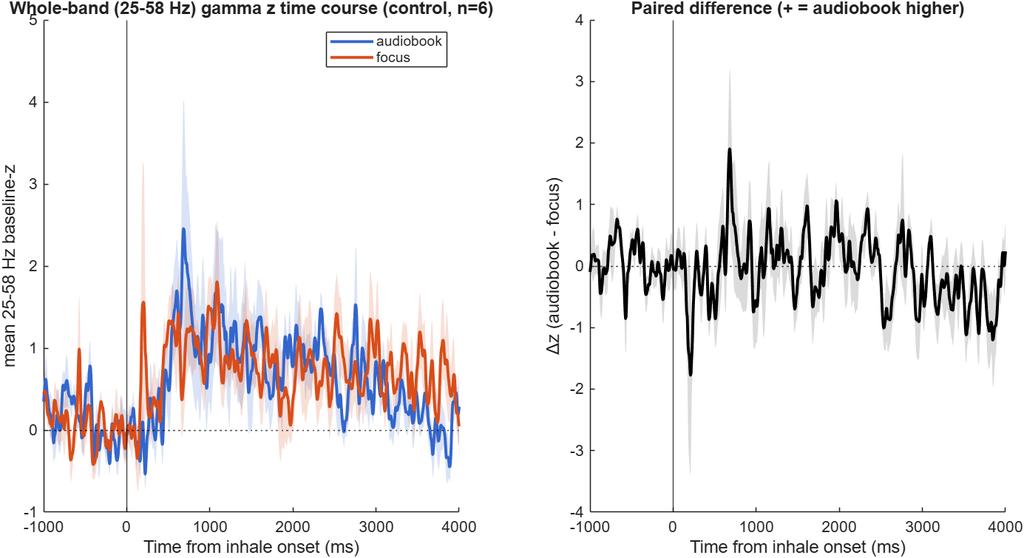

Whole‑band 25–58 Hz z by window (audiobook − focus)

| window_ms | mean_audiobook | mean_focus | diff_A_minus_F | dz | t_p |
| --- | --- | --- | --- | --- | --- |
| 0-500 | 0.078 | 0.410 | -0.333 | -0.528 | 0.252 |
| 500-1000 | 1.307 | 1.072 | 0.234 | 0.159 | 0.713 |
| 1000-1500 | 1.118 | 1.024 | 0.094 | 0.087 | 0.840 |
| 1500-2000 | 0.838 | 0.649 | 0.189 | 0.228 | 0.601 |
| 2000-3000 | 0.775 | 0.772 | 0.003 | 0.005 | 0.992 |
| 0-2000 | 0.836 | 0.788 | 0.048 | 0.056 | 0.896 |

## 2.2 Theta power time course (4–8 Hz, baseline‑z)

The same shape in theta: focus rises first (peaks ~150 ms), audiobook rises later and higher (~700 ms); the paired difference is negative early, positive later.

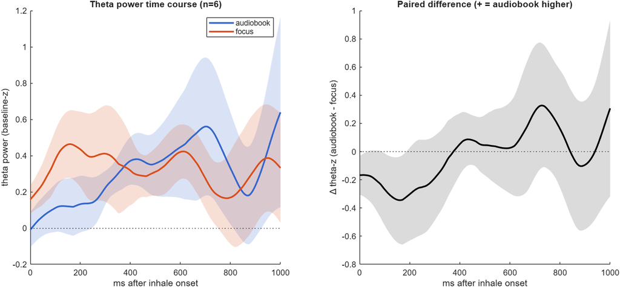

## 2.3 Quantifying the timing (peak latency, centroid, cross‑correlation lag)

Collapsing each subject’s first‑second response to a single timing number, **CP excluded (n=5)**. Every measure points the same way — focus earlier / audiobook lags — with the gamma peak latency the strongest (dz = 0.90, ~196 ms; 4/5 subjects), theta centroid next (dz = 0.72), and the gamma cross‑correlation lag independently agreeing (audiobook +124 ms).

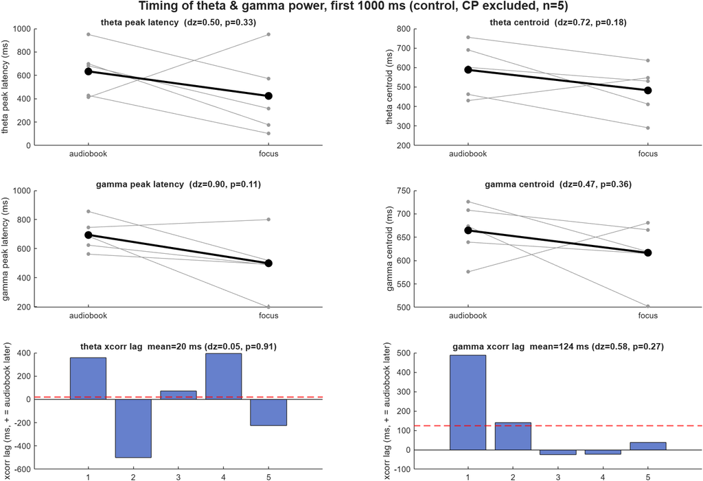

Paired timing statistics (n=5). xcorr lag: + = audiobook later than focus (one‑sample vs 0).

| band | metric | n | mean_audiobook | mean_focus | diff | dz | t_p | wilcox_p |
| --- | --- | --- | --- | --- | --- | --- | --- | --- |
| theta | peakLatMs | 5 | 634.400 | 423.200 | 211.200 | 0.496 | 0.329 | 0.625 |
| theta | riseSlope | 5 | 1.283 | 2.661 | -1.377 | -0.474 | 0.349 | 0.438 |
| theta | centroidMs | 5 | 588.190 | 483.524 | 104.666 | 0.715 | 0.185 | 0.188 |
| gamma | peakLatMs | 5 | 694.800 | 498.800 | 196.000 | 0.903 | 0.114 | 0.125 |
| gamma | riseSlope | 5 | 3.648 | 9.119 | -5.471 | -0.446 | 0.375 | 0.625 |
| gamma | centroidMs | 5 | 664.633 | 616.531 | 48.102 | 0.465 | 0.357 | 0.312 |
| theta | xcorrLagMs | 5 | NaN | NaN | 20.000 | 0.052 | 0.913 | 1.000 |
| gamma | xcorrLagMs | 5 | NaN | NaN | 124.000 | 0.579 | 0.265 | 0.312 |

Theta’s cross‑correlation lag is null because its time course is too bumpy for a clean shift estimate — peak/centroid capture theta timing better, while cross‑correlation works for the smoother gamma envelope.

## 2.4 Ridge‑frequency sweep — a shared gamma chirp, no condition difference

Tracking the 25–58 Hz ridge frequency per breath (canonical pipeline: superlet → per‑freq whole‑window z → `ridge_track`) reveals a robust, **breath‑locked frequency chirp**: the ridge rises from ~40 Hz at inhale onset to a **~45–46 Hz peak around 500–650 ms** and then falls back toward ~42–43 Hz. **This chirp is essentially identical in both conditions.** Gating the ridge to only supra‑threshold gamma points (ridge **z > 3**) sharpens the estimate but reveals no condition difference: the session‑wise ATB − baseline difference (right panel) straddles zero across the whole first 1.5 s, and the scalar mean gated ridge frequency is null — **baseline 43.5 Hz vs ATB 43.9 Hz, dz = −0.48, t p = 0.22, Wilcoxon p = 0.25 (n = 8 sessions)** (raw, ungated sweep also null). The earlier “sweep‑shape difference” impression did not survive. The chirp is a real, reproducible feature of the breath‑locked gamma response — but **not** a condition discriminator.

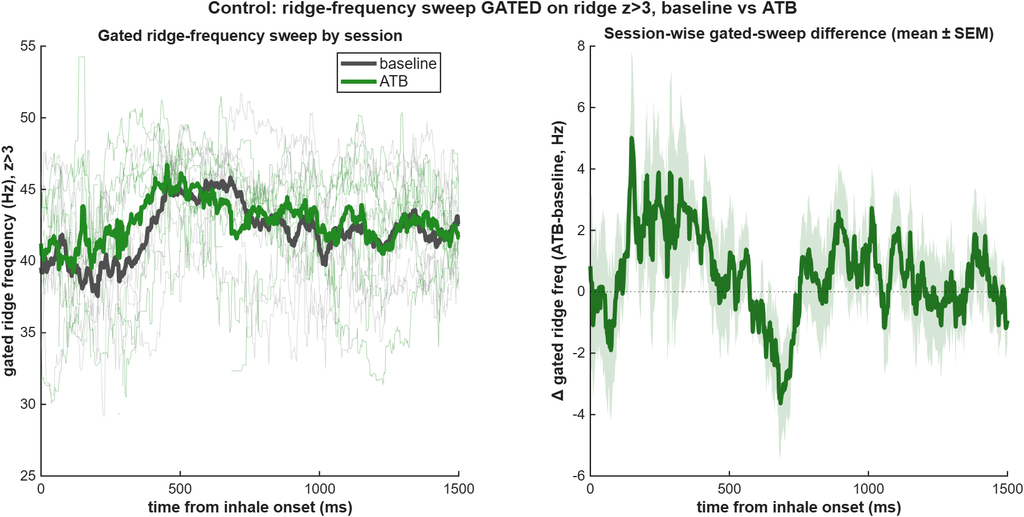

Mean gated (z>3) ridge frequency, baseline vs ATB (paired, n=8 sessions)

| n | mean_baseline_Hz | mean_ATB_Hz | diff | dz | t_p | wilcox_p |
| --- | --- | --- | --- | --- | --- | --- |
| 8 | 43.507 | 43.864 | -0.356 | -0.481 | 0.216 | 0.25 |

# 3 The decoder — the difference is real (robust omnibus)

A within‑subject, leakage‑controlled classifier (PCA→LDA, 5‑fold OOF) on the **gamma** feature vector, with a 500‑permutation null and a **temporal‑confound control** (breath order alone; and gamma after detrending each feature on breath order). This is the one analysis that reaches strong significance, and it is what tells us the timing description above is reading a *real* difference.

Per‑subject decoding: gamma, gamma‑detrended, time‑only OOF‑AUC (500‑perm p)

| subject | nBreath | nFocus | auc_gamma | auc_gamma_detrended | auc_time_only | perm_p_gamma | perm_p_detrended |
| --- | --- | --- | --- | --- | --- | --- | --- |
| AD | 293 | 162 | 0.613 | 0.700 | 0.519 | 0.008 | 0.002 |
| AS | 134 | 57 | 0.476 | 0.480 | 0.580 | 0.587 | 0.559 |
| BW | 107 | 39 | 0.926 | 0.906 | 0.706 | 0.002 | 0.002 |
| CP | 93 | 26 | 0.764 | 0.741 | 0.785 | 0.002 | 0.002 |
| RX | 101 | 29 | 0.714 | 0.649 | 0.784 | 0.008 | 0.032 |
| TI | 141 | 74 | 0.616 | 0.616 | 0.532 | 0.042 | 0.042 |

Group (n=6): mean AUC, subjects>chance, Wilcoxon vs 0.5, Fisher‑combined permutation p

| measure | mean_auc | n_gt_chance | wilcox_p | fisher_perm_p |
| --- | --- | --- | --- | --- |
| gamma | 0.685 | 5 | 0.063 | 0 |
| gamma_detrended | 0.682 | 5 | 0.063 | 0 |
| time_only | 0.651 | 6 | 0.031 | NA |

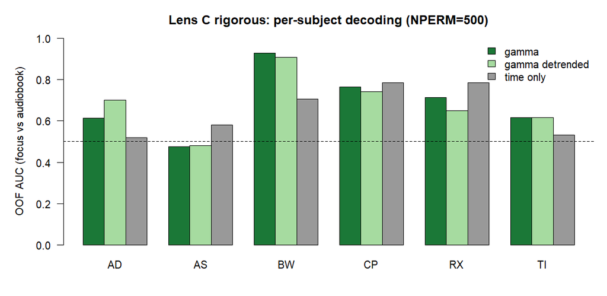

# 4 Extending to the intervention: Dupi S1 → S2, and a late window

Two questions: (a) does the control timing pattern appear in the Dupi cohort, and how does it change from **session 1 to session 2**; (b) is there a **late window** (3000–4000 ms) where focus gamma exceeds audiobook. Here **theta (4–8 Hz)** and **gamma (25–58 Hz)** band‑z come from the same spectro2 maps (theta = mean 4–8 Hz of the low band), so all groups are measured identically. Three metrics per breath: **time‑to‑peak** of the band‑z (0–1000 ms), and the **whole‑band max‑z** averaged over an **early (100–500 ms)** and a **late (3000–4000 ms)** window. Control excludes CP.

## 4.1 Time courses by group

Focus’s post‑inhale response is earlier/higher than audiobook in **Control** and, most strongly, in **Dupi S2**; the pattern is muted at **Dupi S1**.

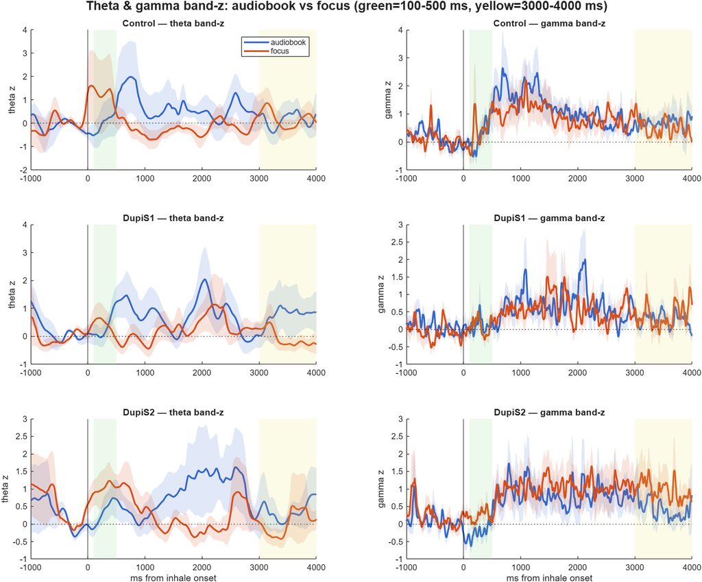

## 4.2 Metrics by group (audiobook vs focus)

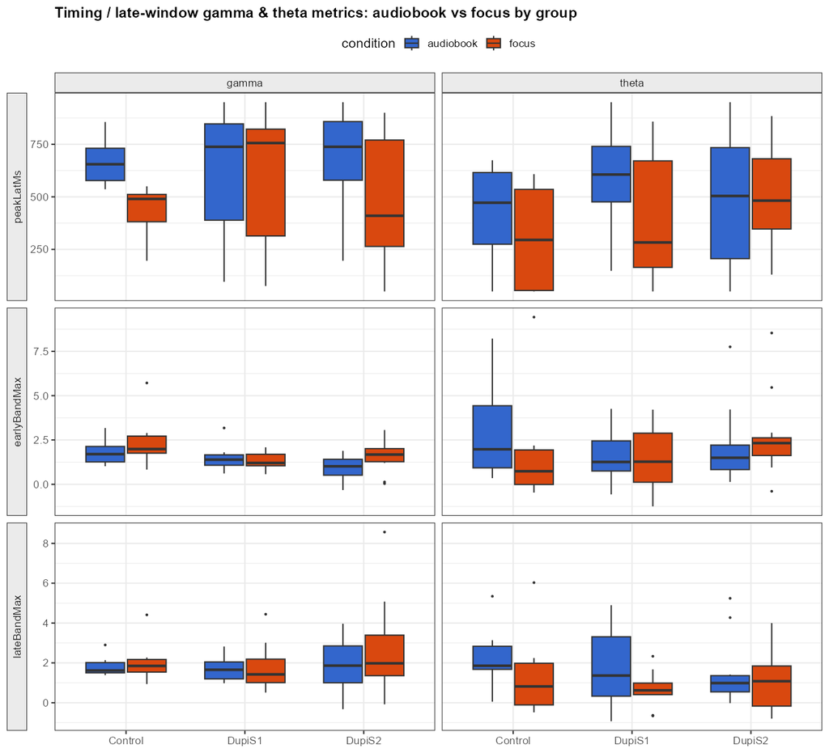

Gamma, paired audiobook−focus by group (peakLat: +dz = focus earlier; bandMax: −dz = focus higher)

| band | metric | group | n | mean_audiobook | mean_focus | dz | t_p | wilcox_p |
| --- | --- | --- | --- | --- | --- | --- | --- | --- |
| gamma | peakLatMs | Control | 5 | 673.800 | 428.400 | 1.454 | 0.031 | 0.062 |
| gamma | peakLatMs | DupiS1 | 10 | 618.364 | 603.200 | 0.115 | 0.724 | 0.695 |
| gamma | peakLatMs | DupiS2 | 11 | 673.455 | 487.091 | 0.519 | 0.116 | 0.206 |
| gamma | earlyBandMax | Control | 5 | 1.855 | 2.638 | -0.582 | 0.263 | 0.625 |
| gamma | earlyBandMax | DupiS1 | 10 | 1.448 | 1.333 | 0.133 | 0.684 | 0.557 |
| gamma | earlyBandMax | DupiS2 | 11 | 0.937 | 1.554 | -0.714 | 0.039 | 0.032 |
| gamma | lateBandMax | Control | 5 | 1.776 | 2.313 | -0.445 | 0.376 | 0.438 |
| gamma | lateBandMax | DupiS1 | 10 | 1.717 | 1.810 | -0.014 | 0.965 | 1.000 |
| gamma | lateBandMax | DupiS2 | 11 | 1.825 | 2.732 | -0.484 | 0.140 | 0.123 |

Two effects reach significance: **gamma peaks ~246 ms earlier in focus in controls** (dz = 1.45, t p = 0.031) — the “earlier gamma in focus” claim, now significant on the whole‑band measure — and **early‑window gamma is higher in focus at Dupi S2** (dz = −0.71, p = 0.039; Wilcoxon 0.032). Dupi S2 also shows the strongest late‑window focus > audiobook. Dupi S1 shows neither, i.e. the effect is present in controls, **absent at S1, and (re)emerges by S2**. Theta is directionally similar but noisier (no group survives).

## 4.3 The late window (3000–4000 ms)

Late window 3000–4000 ms, gamma band‑z (focus − audiobook)

| group | n | mean_audiobook | mean_focus | focus_minus_audiobook | dz | t_p | wilcox_p |
| --- | --- | --- | --- | --- | --- | --- | --- |
| Control | 7 | 0.696 | 0.512 | -0.184 | -0.174 | 0.661 | 0.938 |
| DupiS1 | 10 | 0.324 | 0.392 | 0.068 | 0.079 | 0.809 | 0.846 |
| DupiS2 | 11 | 0.426 | 0.967 | 0.541 | 0.458 | 0.160 | 0.206 |
| DupiS3 | 6 | -0.049 | 0.082 | 0.131 | 0.184 | 0.671 | 1.000 |

## 4.4 Within‑participant S1 → S2 change

For the 9‑participant Dupi subset with **both** S1 and S2 breathing sessions, the focus‑vs‑audiobook **contrast** at each session (+ = focus earlier / higher), and its S1→S2 change:

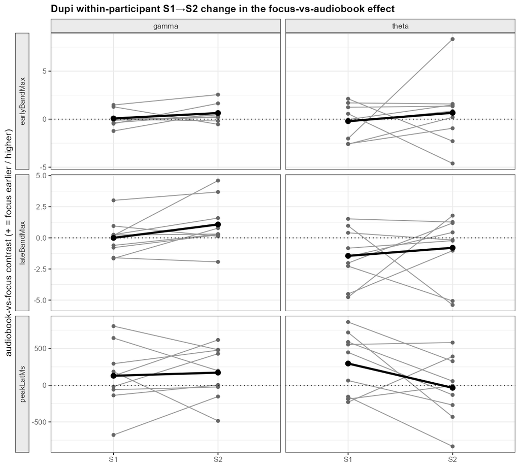

Dupi S1→S2 change in the focus−audiobook contrast (paired within participant, n=9)

| band | metric | n | mean_S1 | mean_S2 | mean_delta | dz | t_p | wilcox_p |
| --- | --- | --- | --- | --- | --- | --- | --- | --- |
| gamma | earlyBandMax | 9 | 0.071 | 0.635 | 0.563 | 0.480 | 0.188 | 0.098 |
| gamma | lateBandMax | 9 | -0.001 | 1.077 | 1.077 | 0.684 | 0.074 | 0.055 |
| gamma | peakLatMs | 9 | 129.333 | 172.000 | 42.667 | 0.098 | 0.776 | 0.652 |
| theta | earlyBandMax | 9 | -0.214 | 0.658 | 0.872 | 0.194 | 0.576 | 0.496 |
| theta | lateBandMax | 9 | -1.447 | -0.799 | 0.648 | 0.171 | 0.621 | 0.496 |
| theta | peakLatMs | 9 | 296.222 | -35.111 | -331.333 | -0.626 | 0.097 | 0.155 |

The **gamma late‑window focus effect grows from S1 (≈0) to S2 (+1.08)** within participants (dz = 0.68, Wilcoxon p = 0.055), and the early‑window effect grows too (dz = 0.48). So the focus > audiobook gamma difference is not static — it **increases across intervention sessions**, consistent with the between‑group S1 vs S2 picture but now shown within the same people.

## 4.5 Does the S1→S2 neural change track olfactory change?

Correlating each participant’s S1→S2 change in the focus−audiobook contrast with their S1→S2 change in the olfactory composite:

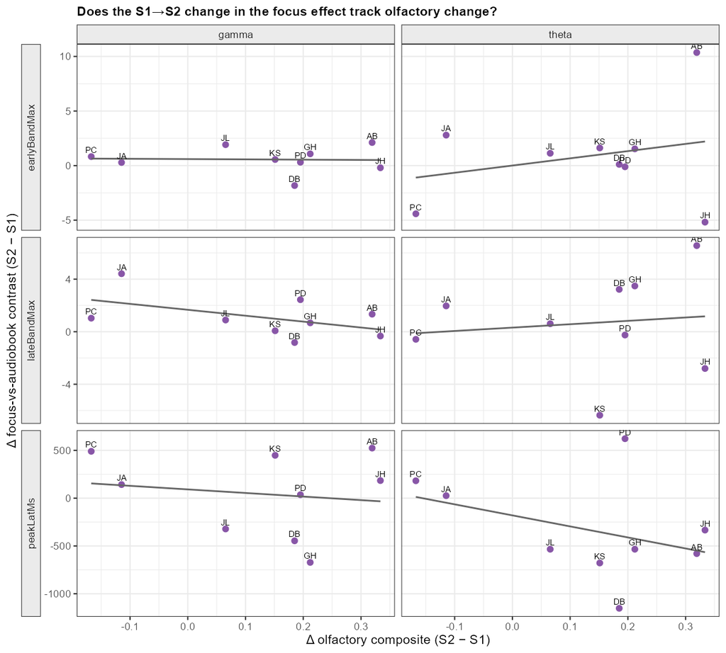

Correlation: S1→S2 neural contrast change vs S1→S2 olfactory‑composite change (n=9)

| band | metric | n | r_pearson | p_pearson | r_spear | p_spear |
| --- | --- | --- | --- | --- | --- | --- |
| gamma | earlyBandMax | 9 | -0.040 | 0.919 | -0.017 | 0.982 |
| gamma | lateBandMax | 9 | -0.499 | 0.171 | -0.317 | 0.410 |
| gamma | peakLatMs | 9 | -0.150 | 0.700 | -0.050 | 0.912 |
| theta | earlyBandMax | 9 | 0.257 | 0.504 | -0.050 | 0.912 |
| theta | lateBandMax | 9 | 0.119 | 0.761 | 0.233 | 0.552 |
| theta | peakLatMs | 9 | -0.381 | 0.311 | -0.218 | 0.574 |

**No correlation reaches significance** (all p > 0.17; strongest is gamma late‑window r = −0.50, ns). So while the focus‑gamma effect *grows* from S1 to S2 at the group/within‑participant level, that growth does **not** demonstrably track each individual’s olfactory change at n = 9 — the brain–behavior link is untested rather than absent, and is the key target for a larger sample.

# 5 Power analysis

The paired timing effects are large but the study is tiny. For a paired t‑test (α = 0.05), the sample size needed to detect each **observed** effect at 80/90% power, and the current power at n = 5–6:

Power for the observed timing effects (n=5, CP excluded)

| effect | dz | power_n5 | power_n6 | n_for_80 | n_for_90 |
| --- | --- | --- | --- | --- | --- |
| gamma peakLatMs | 0.90 | 0.34 | 0.43 | 12 | 15 |
| theta centroidMs | 0.72 | 0.23 | 0.30 | 18 | 23 |
| gamma xcorrLagMs | 0.58 | 0.17 | 0.21 | 26 | 34 |
| theta peakLatMs | 0.50 | 0.14 | 0.17 | 34 | 45 |
| gamma centroidMs | 0.47 | 0.13 | 0.15 | 39 | 51 |
| theta xcorrLagMs | 0.05 | 0.03 | 0.03 | 2892 | 3871 |

Planning grid: paired t‑test, α = 0.05, across a plausible effect‑size range

| dz | n_for_80 | n_for_90 | power_at_n5 | power_at_n12 |
| --- | --- | --- | --- | --- |
| 0.4 | 52 | 68 | 0.10 | 0.24 |
| 0.5 | 34 | 44 | 0.14 | 0.35 |
| 0.6 | 24 | 32 | 0.18 | 0.47 |
| 0.7 | 19 | 24 | 0.23 | 0.60 |
| 0.8 | 15 | 19 | 0.28 | 0.71 |
| 0.9 | 12 | 16 | 0.34 | 0.81 |
| 1.0 | 10 | 13 | 0.40 | 0.88 |
| 1.2 | 8 | 10 | 0.53 | 0.97 |

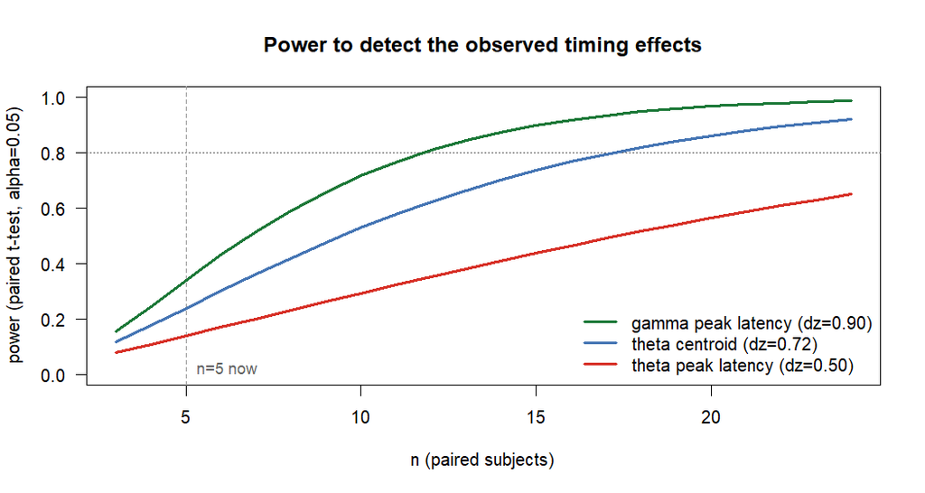

**Read‑out.** At n = 5, even the large gamma‑latency effect (dz = 0.90) has only **34%** power — so its non‑significance is expected. Confirming it at 80% power needs **n ≈ 12** (≈7 more control subjects with both conditions); theta centroid (dz = 0.72) needs n ≈ 18. The decoder, by contrast, is already significant because it aggregates within‑subject evidence.

# 6 Broader context: what does *not* drive it

## 6.1 The peak‑latency effect is an argmax artifact (block trajectories)

Building block‑level **grand‑mean** gamma band‑z in the **identical** superlet→myChanZscore pipeline (average over breaths within each block, then across the 8 control sessions) removes the per‑session argmax instability. At this level focused breathing does **not** rise earlier: **baseline’s grand mean reaches its first prominent peak ~530 ms** while **ATB’s comparable peak is later (~1090 ms)**, and the per‑session traces overlap heavily. The per‑session “peak latency” that produced dz = 1.61 (Grant figs) is jumping between the multiple bumps of a noisy multi‑peak trace — an **argmax artifact**, not a genuinely earlier response. This is the basis for the post‑hoc correction in the Overview.

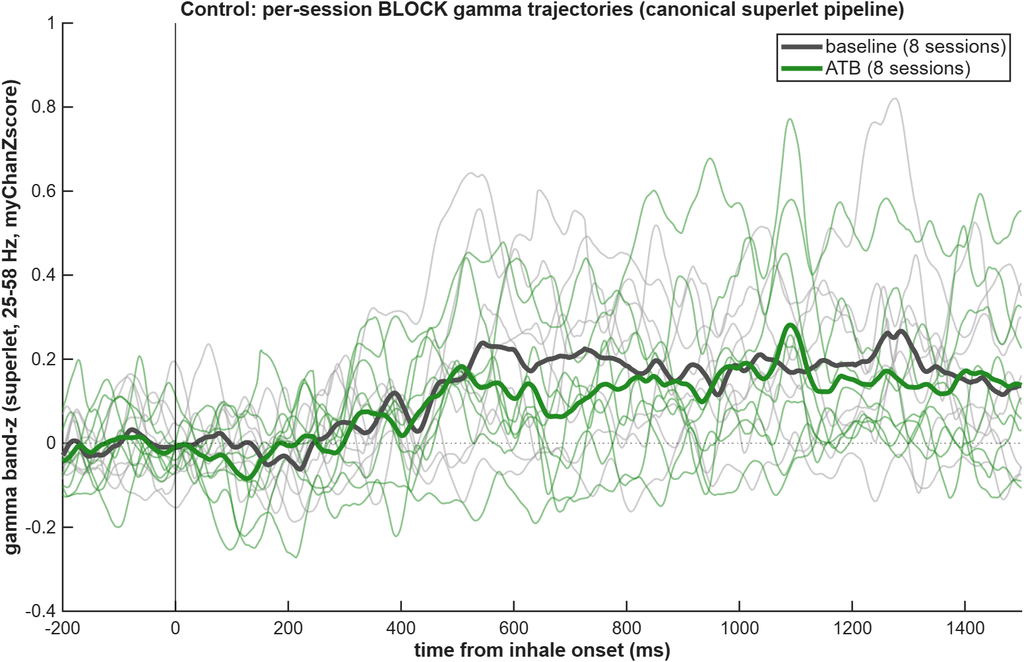

## 6.2 Univariate sweep — no single metric survives correction

Every per‑breath gamma metric, paired across subjects (BH‑FDR over 93 metrics): **0 survive** (min q = 0.76). The apparent leads must be read with care — e.g. `p3_aucZ` (which looked strongest) is a **breath‑duration artifact**: its *integrated* form rises in focus only because focus breaths are longer, while the duration‑independent `p3_rpowZ`/`p3_rpowDb` show no such effect. The genuinely duration‑independent leads are `w5_rpowDb` (late gamma, higher audiobook) and `freqJitter`, both fragile.

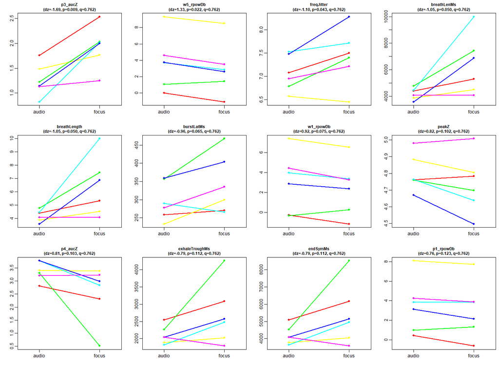

## 6.3 Breathing itself differs (the manipulation)

All 10 airflow/morphology metrics are larger in focused breathing (breaths ~2.2 s longer, ~23% larger inhale volume; dz ≈ 0.7–1.1). This is the intended manipulation and a **confound** for any raw gamma comparison not normalised for breath timing — which is exactly why the *timing* framing (and the detrended decoder) matters.

## 6.4 Theta–gamma coupling and respiratory entrainment — weak, no difference

4–8 Hz inter‑breath **ITPC** is low (~0.10–0.15, near the chance floor for ~70 breaths), marginally higher in focus. Theta→gamma **PAC** (Tort MI) is very weak overall (~1×10⁻⁴) with no significant period differences (largest: focus higher in inhale‑rise/exhale‑fall, dz ≈ −0.6, ns). Note: coupling here is *within‑breath* PAC; the session‑level respiration‑phase coupling metric in the main pipeline was **not** condition‑specific (identical values written to both conditions) and is not reported.

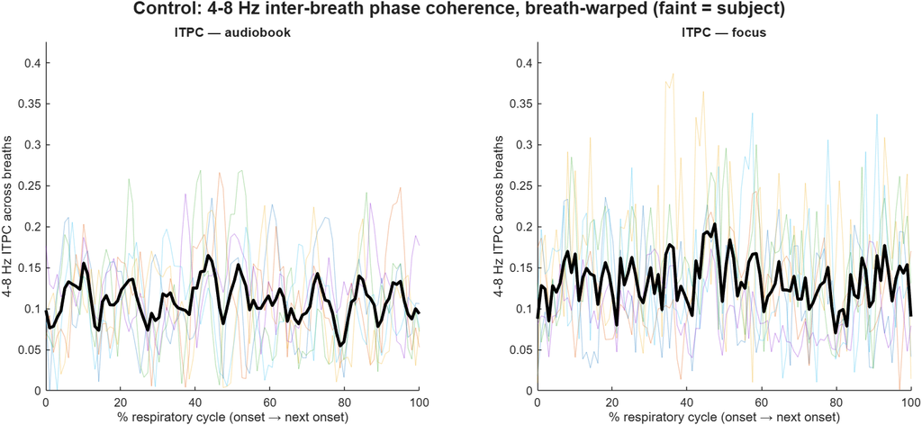

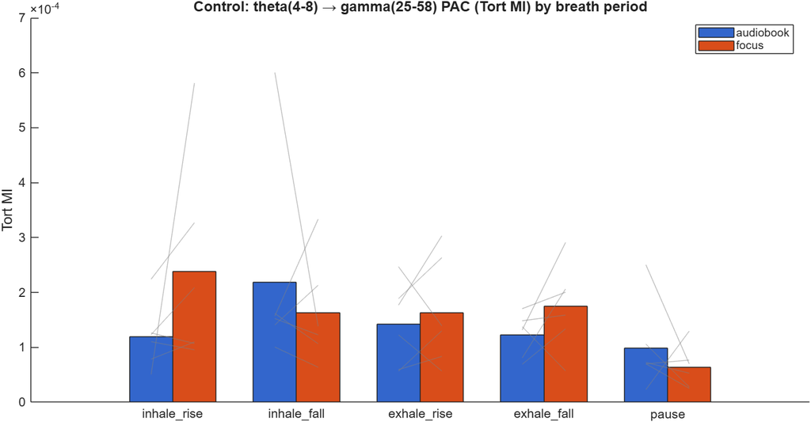

Theta→gamma PAC (Tort MI) by breath period, paired (n=6)

| period | n | mean_audiobook | mean_focus | diff | dz | t_p | wilcox_p |
| --- | --- | --- | --- | --- | --- | --- | --- |
| inhale_rise | 6 | 0 | 0 | 0 | -0.575 | 0.218 | 0.156 |
| inhale_fall | 6 | 0 | 0 | 0 | 0.257 | 0.557 | 0.844 |
| exhale_rise | 6 | 0 | 0 | 0 | -0.230 | 0.597 | 0.562 |
| exhale_fall | 6 | 0 | 0 | 0 | -0.601 | 0.201 | 0.219 |
| pause | 6 | 0 | 0 | 0 | 0.368 | 0.409 | 0.438 |

## 6.5 Theta (4–8 Hz) in the early window (0–500 ms): ITPC and power

A focused test: do the conditions differ in **early‑window (0–500 ms) theta**? Two measures, both in the canonical pipeline — **power** as superlet band‑z (mean 4–8 Hz of the spectro2 low band, baseline −500..−100 ms, winsorized ±10) and **ITPC** as 4–8 Hz analytic‑phase inter‑trial coherence across breaths, **n‑matched** between conditions (subsample to the smaller breath count, 30 reps) to remove the trial‑count bias. Paired across **8 control sessions** (CP excluded).

**Neither differs significantly.** Early‑window theta **ITPC** is null and sits near the ~0.13 chance floor in both conditions (baseline 0.122 vs ATB 0.107, dz = 0.25, p = 0.51) — if anything marginally higher in baseline. Early‑window theta **power** runs directionally higher in ATB (mean band‑z 1.04 vs −0.00, dz = −0.37, p = 0.33), echoing the weak “focus‑higher‑early” gamma tendency, but it is **not** significant and is **driven largely by one session (AS**, whose ATB band‑z hit the ±10 winsor cap); the max‑z measure is flatter still (dz = −0.14, p = 0.71). So early theta matches the overall picture — a weak, ATB‑higher‑power lean that is not a robust condition difference, and no phase‑locking (ITPC) difference.

[figure not shown]

Early‑window (0–500 ms) theta: power band‑z and ITPC, baseline vs ATB (paired, n=8 sessions)

| metric | n | mean_baseline | mean_ATB | diff | dz | t_p | wilcox_p |
| --- | --- | --- | --- | --- | --- | --- | --- |
| theta power (band-z mean 0-500) | 8 | -0.004 | 1.037 | -1.041 | -0.370 | 0.330 | 0.461 |
| theta power (band-z max 0-500) | 8 | 1.680 | 1.969 | -0.289 | -0.137 | 0.709 | 0.641 |
| theta ITPC (0-500, n-matched) | 8 | 0.122 | 0.107 | 0.015 | 0.246 | 0.510 | 0.312 |

# 7 Synthesis

# 8 Methods

audiobook = `audio` blocks, focusedBreathing = `focus | naturalFocus | slowFocus` blocks; best macBP channel per session (FOOOF‑flattened peak). Groups: Control = OBE (CP excluded — atypical breathing, fewest focus breaths, reversed the gamma‑latency effect); Dupi S1/S2 = intervention sessions 1/2. Per‑breath gamma/theta from the superlet ridge pipeline (`extract_gamma_session`); spectrogram z‑maps (`extract_spectro_session`, baseline −500..−100 ms). Control‑only timing (§2): theta 4–8 Hz and gamma 25–58 Hz Butterworth+Hilbert on the best‑channel signal; power baseline‑z; peak/centroid/xcorr over 0–1000 ms. Group analyses (§4): theta = mean 4–8 Hz of the spectro2 low band, gamma = mean 25–58 Hz of the mid band (same z for all groups); band‑z drives time‑to‑peak, whole‑band max‑z drives the 100–500 ms and 3000–4000 ms window means. Decoder: PCA→LDA, 5‑fold OOF AUC, 500‑perm within‑subject null, detrend control. S1→S2: within‑participant contrast (focus−audiobook, or audiobook−focus for latency), paired; olfactory composite from `session_scores.csv`; Pearson/Spearman correlation of S1→S2 neural vs olfactory change. Paired tests within subject (Cohen’s dz); BH‑FDR within the univariate sweep; power via `power.t.test` (paired). Ridge‑frequency sweep (§2.4): `slt_power_cont` (c1=3, order [3 30], F=22:62) → per‑freq whole‑window z → `ridge_track` on 25–58 Hz; the gated sweep keeps only ridge points with z > 3. Block trajectories (argmax‑artifact check): same superlet→band‑z, averaged over breaths within block then across sessions. Early‑window theta (§6): power = superlet band‑z (mean 4–8 Hz of the spectro2 low band); ITPC = 4–8 Hz Butterworth+Hilbert analytic phase, inter‑trial coherence across breaths, n‑matched (30 subsamples to the smaller breath count). Scripts: `code/taskcmp_*.{R,m}` (incl. `taskcmp_bandmetrics.m`, `taskcmp_groups_gamma.m`, `taskcmp_D_analysis.R`, `taskcmp_grantfigs.R`, `taskcmp_ridge_gated.m`, `taskcmp_superlet_blocks.m`, `taskcmp_theta_early.m`), `taskcmp_latency.m`, `scratch_ridge_bandmax.m`, `scratch_theta_pac.m`, `cluster_perm_audio_focus.m`, `taskcmp_power.R`.

# 9 Grant figs

The two key **gamma** measures for the grant, **baseline** (audiobook / passive listening) vs **ATB** (focused breathing), by group (Control, Dupi S1, Dupi S2). Each connected line is one **session**; **baseline = grey, ATB = forest green**. High‑resolution standalone PNGs: `out/figs/taskcmp/grantfig_gamma_peakLatMs.png` and `grantfig_gamma_earlyBandMax.png`.

## 9.1 Gamma peak latency

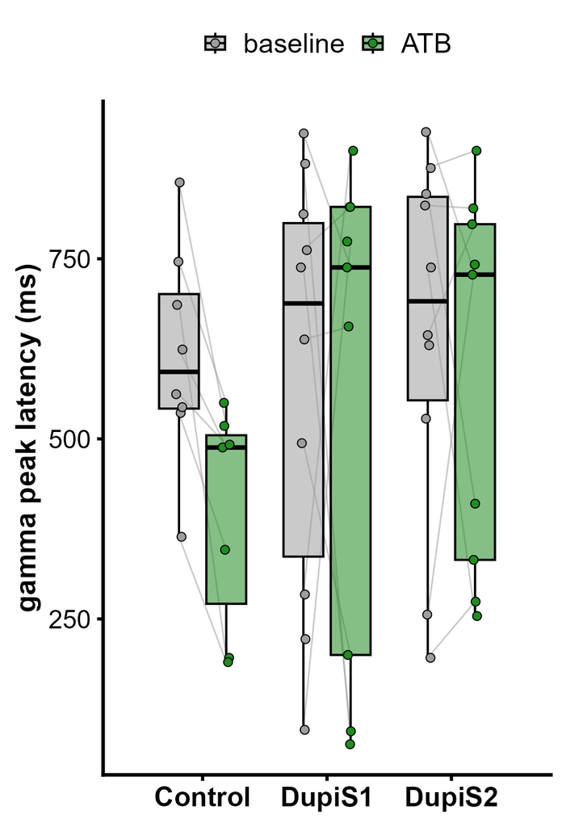

Gamma peaks **earlier during ATB than baseline** — robust in controls on the expanded sample: **dz = 1.61 across 7 sessions** (7/7 show ATB earlier; SP_2’s ATB peak hit the search‑window edge → dropped as an invalid latency). The effect is muted at Dupi S1 and re‑emerges at S2.

> **⚠ This panel is an argmax artifact — do not use it as a standalone grant metric.** The same superlet→band‑z pipeline, taken to the **block grand‑mean** level, does **not** reproduce “ATB earlier” (baseline’s grand mean peaks first, ~530 ms vs ~1090 ms — see *Broader context → argmax artifact*), and both the raw and z > 3‑gated ridge‑frequency sweeps (§2.4) show **no condition difference**. The per‑session argmax jumps between bumps of a noisy multi‑peak trace. The defensible condition differences are the early band‑max (weak, below) and, above all, the **multivariate decoder** (§3). Retained here as the figure that prompted the correction.

## 9.2 Gamma early band‑max (100–500 ms)

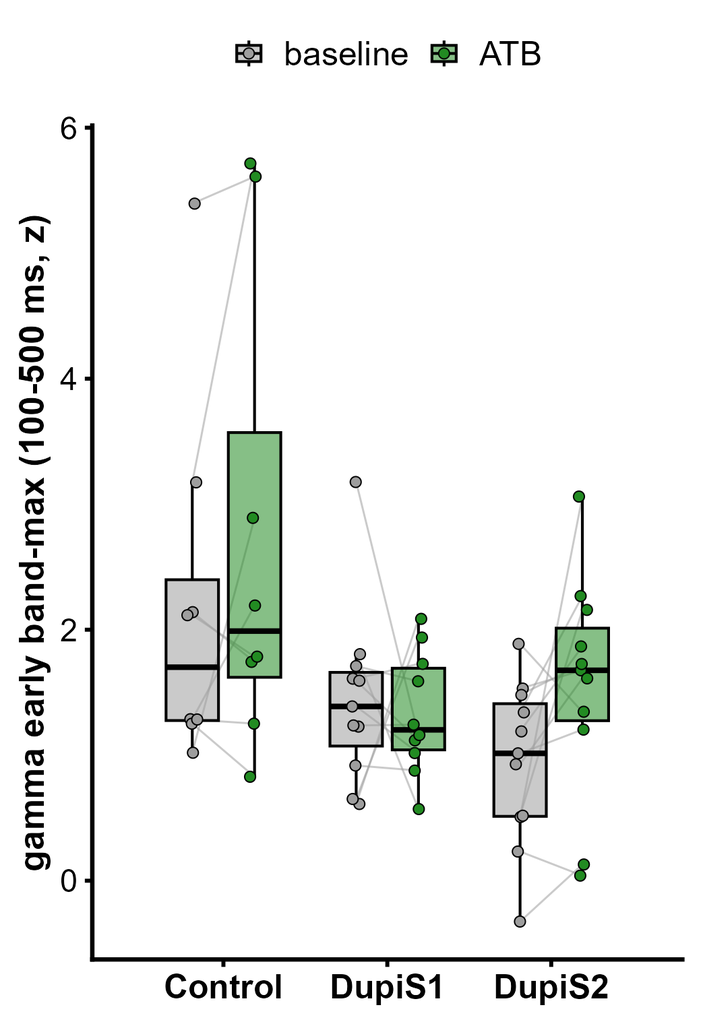

Early gamma is **higher during ATB than baseline** — significant at Dupi S2 (dz = −0.71, p = 0.039), directionally present in controls (dz = −0.48, n = 8). This is the weaker, mixed measure within controls but the more intervention‑sensitive one (see interaction below).

## 9.3 Power

Power: raw control paired difference, and the group×condition interaction (Control × Dupi S1)

| measure | test | effect | effect_type | n_now | power_now | n_for_80 |
| --- | --- | --- | --- | --- | --- | --- |
| peakLatMs | control baseline-vs-ATB (paired) | 1.61 | dz | 7 | 0.94 | 6 |
| peakLatMs | interaction Control x DupiS1 (two-sample on ATB-baseline) | -0.39 | d | 7 vs 8 | 0.10 | 104 |
| earlyBandMax | control baseline-vs-ATB (paired) | -0.48 | dz | 8 | 0.22 | 36 |
| earlyBandMax | interaction Control x DupiS1 (two-sample on ATB-baseline) | 0.63 | d | 8 vs 10 | 0.24 | 41 |

- **Raw control difference (paired, baseline vs ATB), expanded control set.** Gamma **peak latency** is the robust effect: **dz = 1.61** (n = 7 sessions with a valid gamma peak), **94% power already at n = 7** and **80% at n = 6** — essentially already powered. **Early band‑max** (dz = −0.48, n = 8) is the weaker measure and needs **n ≈ 36**. (Note: adding the two new controls, and treating sessions as n, moved peak latency from the earlier small‑sample dz = 1.45 (n = 5) to a comparably strong but better‑supported dz = 1.61 (n = 7); the *early* effect, by contrast, softened from dz = −0.58 to −0.48, i.e. it was somewhat inflated at the smaller n.)
- **Group × condition interaction (Control vs Dupi S1)**, i.e. does the ATB−baseline effect differ between healthy controls and impaired session‑1 Dupi. The interaction is larger for **early band‑max** (d = 0.63, **n ≈ 41/group** for 80%) than for **peak latency** (d = −0.39, n ≈ 104/group). So for demonstrating an intervention‑sensitive *interaction*, the early‑band‑max measure is still the more efficient target (~41/group); for a clean *within‑control* effect, peak latency is essentially already powered (n ≈ 6).